## The first step of the analysis is to import and merge the breweries data with beers data and state lat/long data.

# It is then possible to view the top and bottom 6 values in the new, merged data.

```
## # A tibble: 6 x 10
##   Name    Beer_ID   ABV   IBU Brewery_id Style  Ounces Brewery_Name  City  State
##   <chr>     <dbl> <dbl> <dbl>      <dbl> <chr>   <dbl> <chr>         <chr> <chr>
## 1 Pub Be~    1436 0.05     NA        409 Ameri~     12 10 Barrel Br~ Bend  OR
## 2 Devil'~    2265 0.066    NA        178 Ameri~     12 18th Street ~ Gary  IN
## 3 Rise o~    2264 0.071    NA        178 Ameri~     12 18th Street ~ Gary  IN
## 4 Sinist~    2263 0.09     NA        178 Ameri~     12 18th Street ~ Gary  IN
## 5 Sex an~    2262 0.075    NA        178 Ameri~     12 18th Street ~ Gary  IN
## 6 Black ~    2261 0.077    NA        178 Oatme~     12 18th Street ~ Gary  IN
```

```
## # A tibble: 6 x 10
##   Name    Beer_ID   ABV   IBU Brewery_id Style   Ounces Brewery_Name City  State
##   <chr>     <dbl> <dbl> <dbl>      <dbl> <chr>    <dbl> <chr>        <chr> <chr>
## 1 Rocky ~    1035 0.075    NA        425 Americ~     12 Wynkoop Bre~ Denv~ CO
## 2 Belgor~     928 0.067    45        425 Belgia~     12 Wynkoop Bre~ Denv~ CO
## 3 Rail Y~     807 0.052    NA        425 Americ~     12 Wynkoop Bre~ Denv~ CO
## 4 B3K Bl~     620 0.055    NA        425 Schwar~     12 Wynkoop Bre~ Denv~ CO
## 5 Silver~     145 0.055    40        425 Americ~     12 Wynkoop Bre~ Denv~ CO
## 6 Rail Y~      84 0.052    NA        425 Americ~     12 Wynkoop Bre~ Denv~ CO
```

# A map of breweries by state is then constructed, with SIZE representing number of Breweries

[interactive chart not shown]

# A histogram is also built to show breweries by state, with a clearer depiction of absolute number of breweries by state

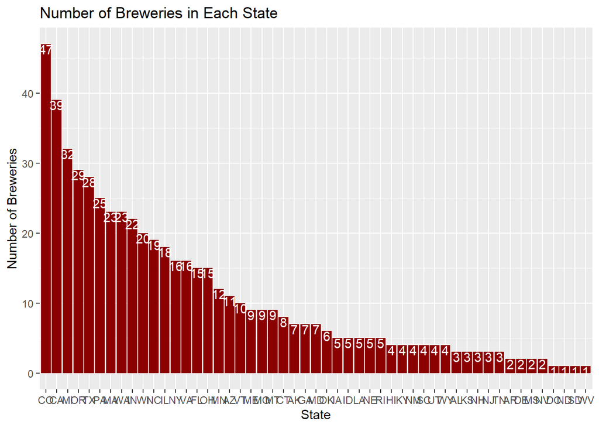

## An important part of data analysis is checking for columns with missing values (NAs). Below shows that only ABV, IBU and Style data # has missing values.

# The Style column only has 5 missing values, so they are replaced with “Unknown”

```
## [1] ""
## [1] ""
## [1] "has NA"
## [1] "has NA"
## [1] ""
## [1] "has NA"
## [1] ""
## [1] ""
## [1] ""
## [1] ""
```

```
##              sapply.df..function.x...
## Name
## Beer_ID
## ABV                            has NA
## IBU                            has NA
## Brewery_id
## Style                          has NA
## Ounces
## Brewery_Name
## City
## State
```

Checking basic regressions to see if imputation of ABV / IBU is possible using the other.

```
##
## Call:
## lm(formula = IBU ~ ABV, data = df)
##
## Residuals:
##     Min      1Q  Median      3Q     Max
## -78.849 -11.977  -0.721  13.997  93.458
##
## Coefficients:
##             Estimate Std. Error t value Pr(>|t|)
## (Intercept)  -34.099      2.326  -14.66   <2e-16 ***
## ABV         1282.037     37.860   33.86   <2e-16 ***
## ---
## Signif. codes:  0 '***' 0.001 '**' 0.01 '*' 0.05 '.' 0.1 ' ' 1
##
## Residual standard error: 19.26 on 1403 degrees of freedom
##   (1005 observations deleted due to missingness)
## Multiple R-squared:  0.4497, Adjusted R-squared:  0.4493
## F-statistic:  1147 on 1 and 1403 DF,  p-value: < 2.2e-16
```

```
##
## Call:
## lm(formula = ABV ~ IBU, data = df)
##
## Residuals:
##       Min        1Q    Median        3Q       Max
## -0.033288 -0.005946 -0.001595  0.004022  0.052006
##
## Coefficients:
##              Estimate Std. Error t value Pr(>|t|)
## (Intercept) 4.493e-02  5.177e-04   86.79   <2e-16 ***
## IBU         3.508e-04  1.036e-05   33.86   <2e-16 ***
## ---
## Signif. codes:  0 '***' 0.001 '**' 0.01 '*' 0.05 '.' 0.1 ' ' 1
##
## Residual standard error: 0.01007 on 1403 degrees of freedom
##   (1005 observations deleted due to missingness)
## Multiple R-squared:  0.4497, Adjusted R-squared:  0.4493
## F-statistic:  1147 on 1 and 1403 DF,  p-value: < 2.2e-16
```

# The below graphs show the median IBU and ABV by state. IBU has some differences among states, but since median ABV is pretty similar #among states,the graph forms a long plateau.

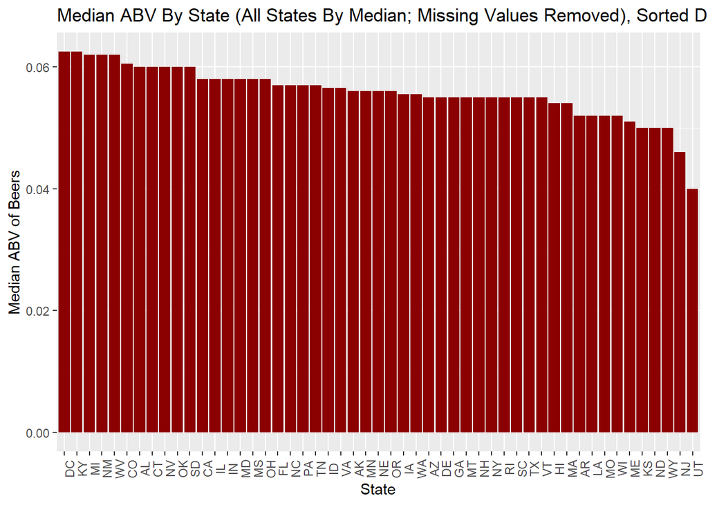

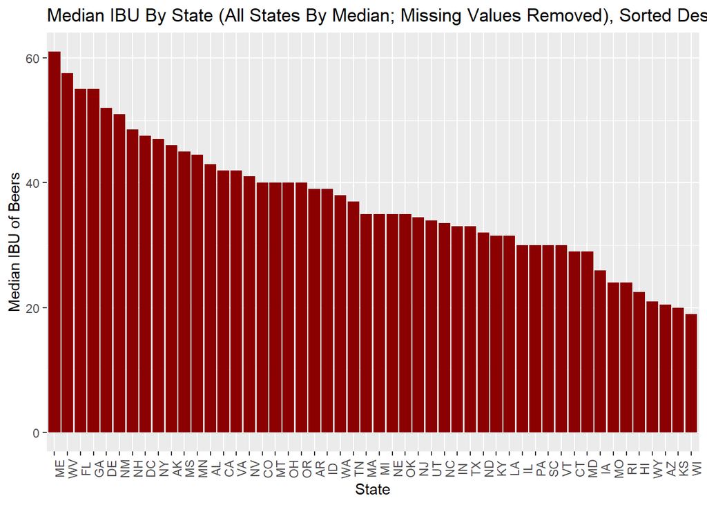

# Medians are a great way to observe ABV & IBU by state, but finding the maximum ABV & IBU beers can also be valuable.

```
## [1] "State with the maximum alcoholic beer: CO, with an alcohol percentage of 12.8%"
```

```
## [1] "State with the maximum bitterness: OR, with an IBU of 138"
```

## Furthermore, there seems to be a pretty strong relationship between ABV and IBU. This is most likely because

## higher concentrations of ingredients (such as hops) are needed to produce higher alcohol beers, resulting in higher alcohol and higher bitterness.

# This strong relationship allows for the construction of a prediction engine to predict IBU given ABV, which will be shown at the end of the document.

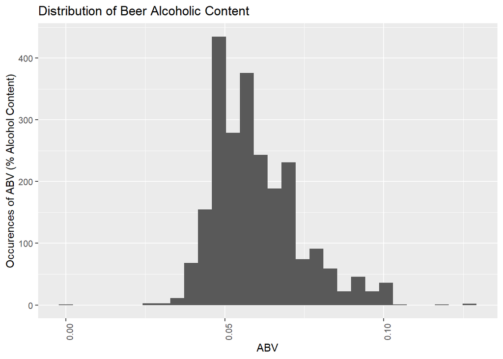

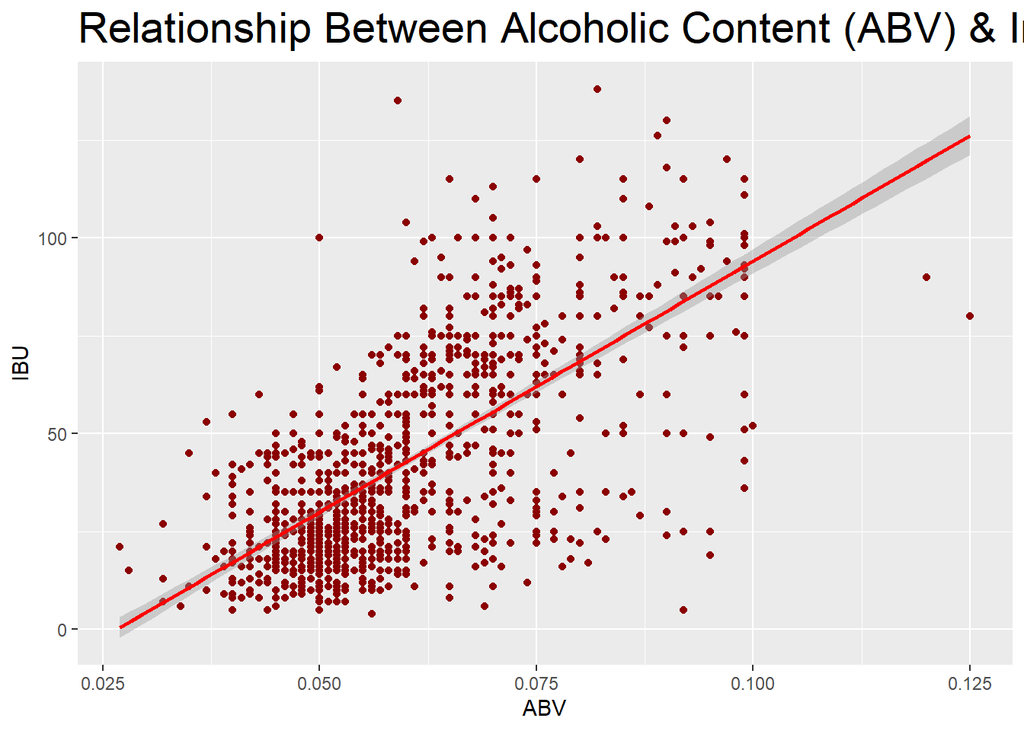

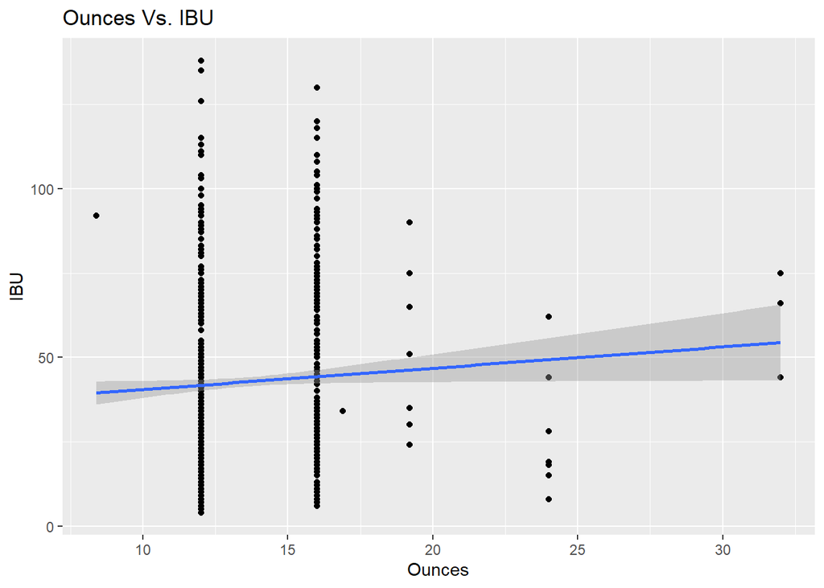

# This word cloud shows the most common words in beer names. It is an interesting graphic showing how popular IPA is in the name of a # beer.

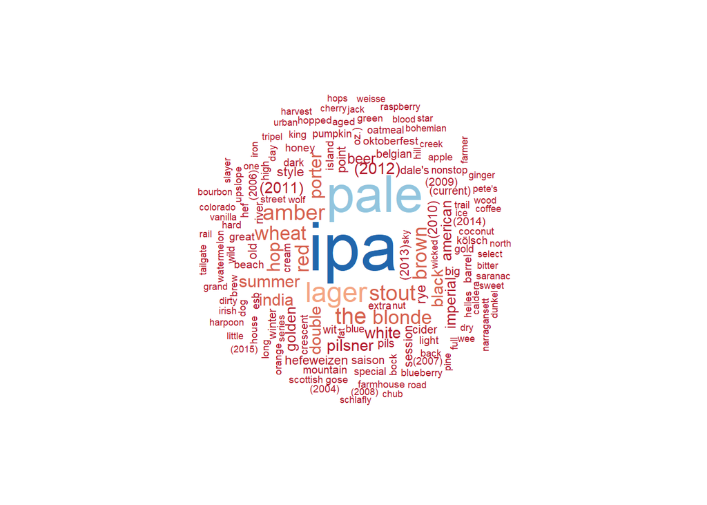

## Since IPAs generally have high hop contents and relatively high alcoholic content, it is possible to predict whether a beer is an IPA given ABV and IBU.

## Leveraging a machine learning algorithm called “K Nearest Neighbors,” the results are promising - nearly a 99% prediction accuracy.

# The KNN (K Nearest Neighbors) algorithm looks at the ‘k’ closest points to a new point

#‘K’ is specified by the analyst and different values of ‘k’ can have different results # New data points are evaluated by the class of the points closest to them # The graph ostensibly shows how many similar points each new beer must be compared to to generate a prediction (k), and the accuracy of each k. # The fact that KNN predicts both IPA and Ales very strongly shows that there is a different in IBU/ABV values for Ales and IPAs

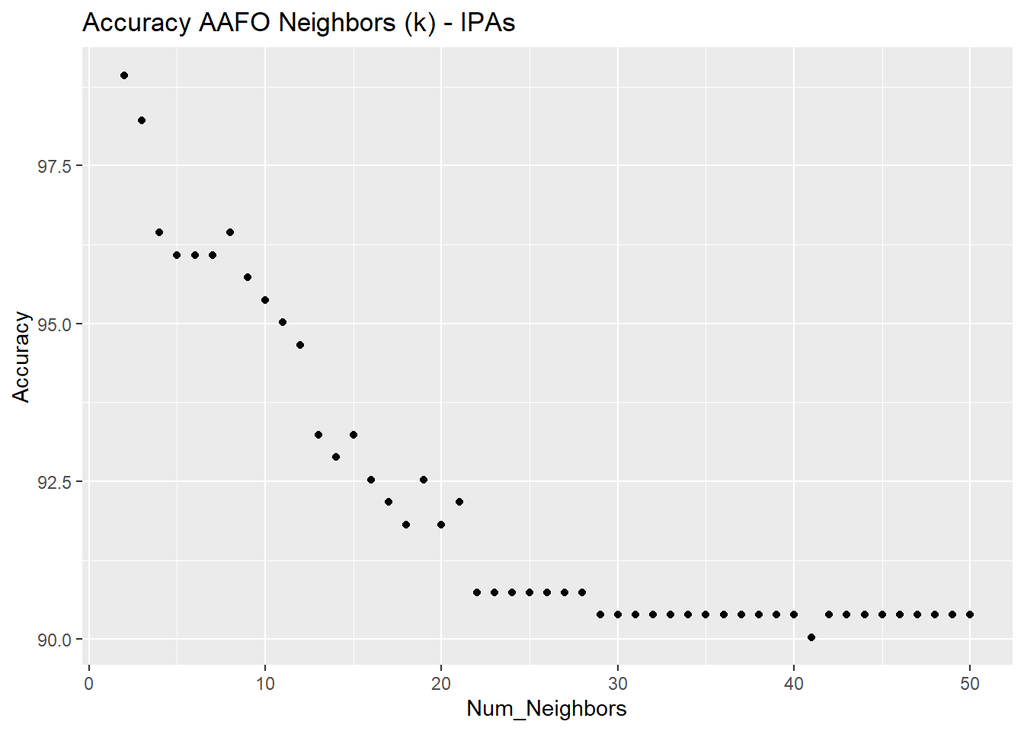

```
## [1] "Confusion Matrix of Ale Classification"
```

```
## Confusion Matrix and Statistics
##
##
## knn_model_Ales   0   1
##              0 205   1
##              1   2  73
##
##                Accuracy : 0.9893
##                  95% CI : (0.9691, 0.9978)
##     No Information Rate : 0.7367
##     P-Value [Acc > NIR] : <2e-16
##
##                   Kappa : 0.9726
##
##  Mcnemar's Test P-Value : 1
##
##             Sensitivity : 0.9903
##             Specificity : 0.9865
##          Pos Pred Value : 0.9951
##          Neg Pred Value : 0.9733
##              Prevalence : 0.7367
##          Detection Rate : 0.7295
##    Detection Prevalence : 0.7331
##       Balanced Accuracy : 0.9884
##
##        'Positive' Class : 0
##
```

## Since Ales generally have high hop contents and relatively high alcoholic content, it is possible to predict whether a beer is an Ale given ABV and IBU.

## Leveraging a machine learning algorithm called “K Nearest Neighbors,” the results are promising - nearly a 99% prediction accuracy.

# The KNN (K Nearest Neighbors) algorithm looks at the ‘k’ closest points to a new point

# ‘K’ is specified by the analyst and different values of ‘k’ can have different results

# New data points are evaluated by the class of the points closest to them

# The graph ostensibly shows how many similar points each new beer must be compared to to generate a prediction (k), and the accuracy of each k.

# The fact that KNN predicts both IPA and Ales very strongly shows that there is a different in IBU/ABV values for Ales and IPAs

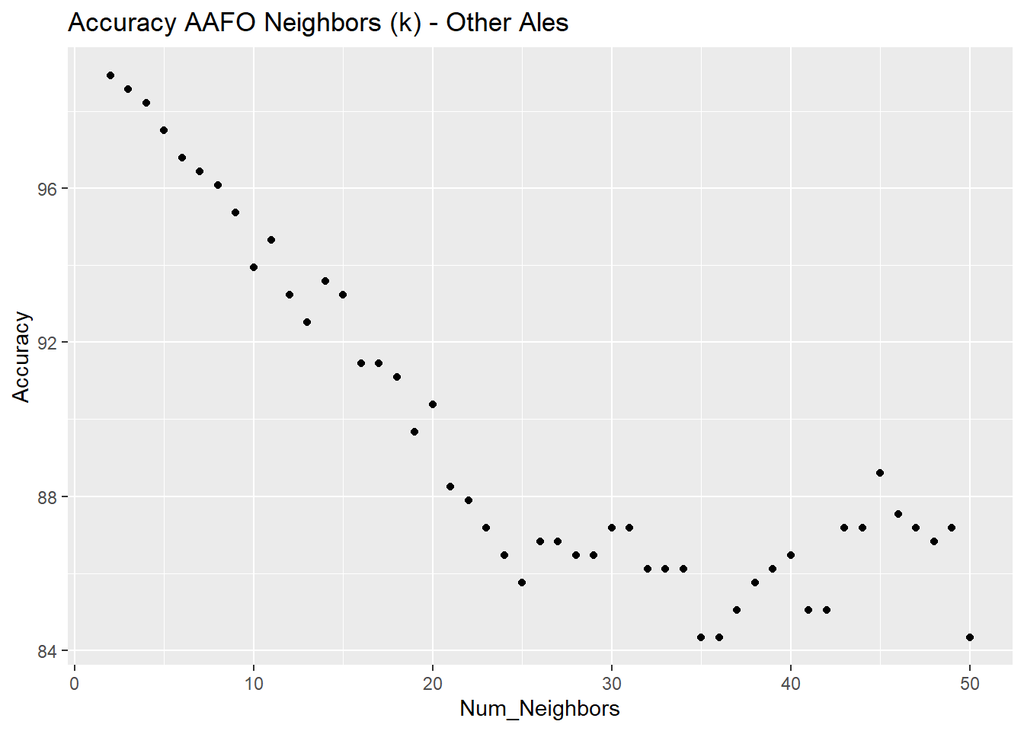

```
## [1] "Confusion Matrix of Ale Classification"
```

```
## Confusion Matrix and Statistics
##
##
## knn_model_Ales   0   1
##              0 170   3
##              1   0 108
##
##                Accuracy : 0.9893
##                  95% CI : (0.9691, 0.9978)
##     No Information Rate : 0.605
##     P-Value [Acc > NIR] : <2e-16
##
##                   Kappa : 0.9776
##
##  Mcnemar's Test P-Value : 0.2482
##
##             Sensitivity : 1.0000
##             Specificity : 0.9730
##          Pos Pred Value : 0.9827
##          Neg Pred Value : 1.0000
##              Prevalence : 0.6050
##          Detection Rate : 0.6050
##    Detection Prevalence : 0.6157
##       Balanced Accuracy : 0.9865
##
##        'Positive' Class : 0
##
```

## Almost 42% of all beers are missing an IBU value

# Using machine learning techniques, it is possible to build an automated prediction engine, based on beer type, ABV and location.

# The process leverages multiple machine learning algorithms and compares the results at the end. The model with the best explanatory power

# is then chosen to predict the missing IBU values.

# After each model, a predicted vs. actual scatter plot is provided to show how well the model predicts values.

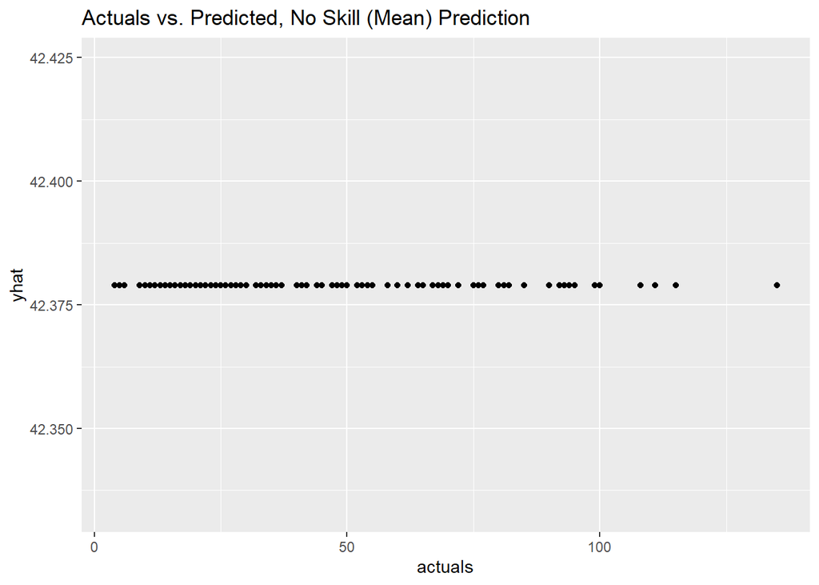

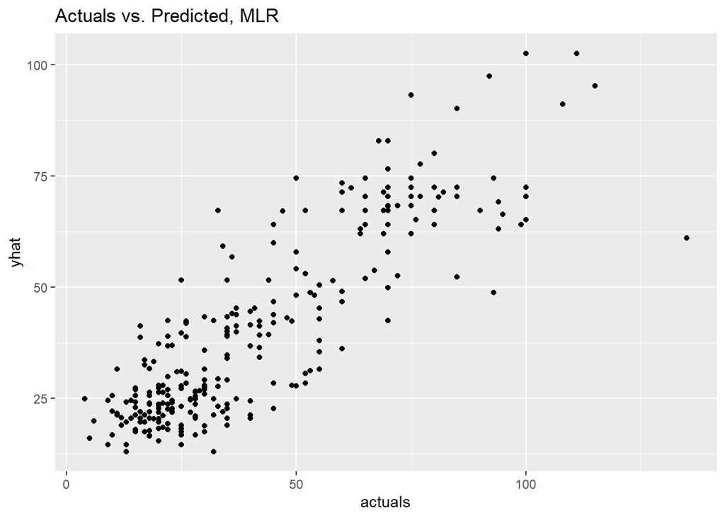

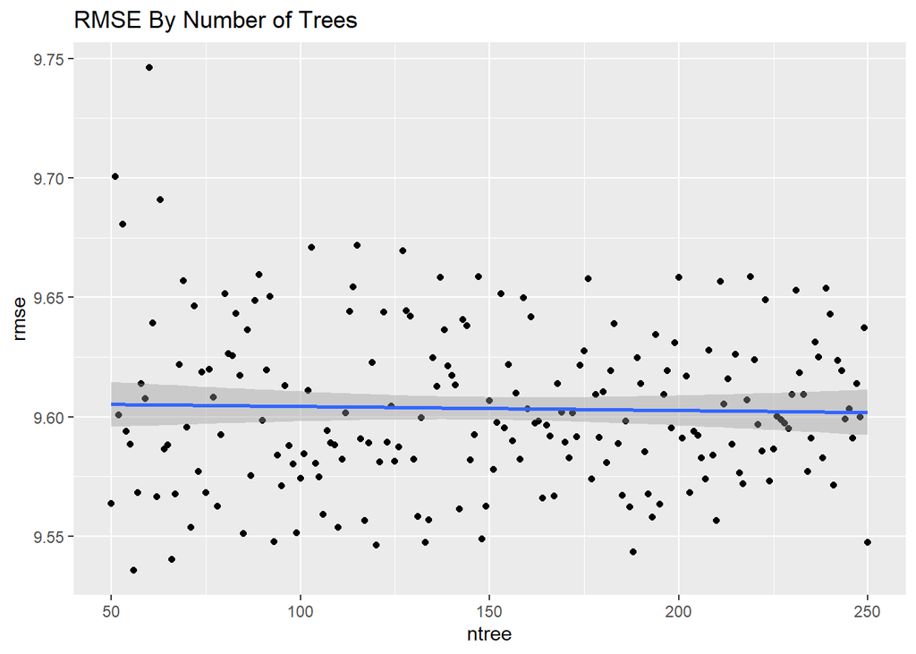

```
##    user  system elapsed
##   27.23    1.41   28.66
```

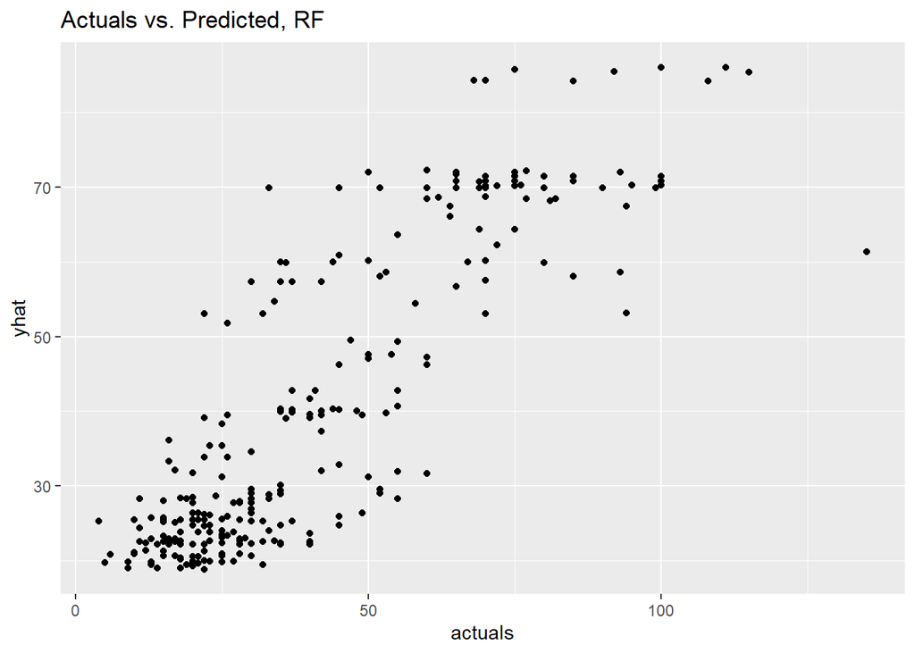

[output not shown]

```
## Fit MSE = 177.0874
## Fit percent variance explained = 74.3
## Median permuted MSE = 5.436625
## Median permuted percent variance explained = 99.205
## Median cross-validation RMSE = 3.397972
## Median cross-validation MBE = 0.3284223
## Median cross-validation MAE = 2.045819
## Range of ks p-values = 0.01370737 0.4701478
## Range of ks D statistic = 0.04218362 0.07785888
## RMSE cross-validation error variance = 0.1684925
## MBE cross-validation error variance = 0.2296594
## MAE cross-validation error variance = 0.03790809
```

```
## [14:11:37] INFO: amalgamation/../src/tree/updater_prune.cc:101: tree pruning end, 46 extra nodes, 0 pruned nodes, max_depth=8
## [14:11:37] INFO: amalgamation/../src/tree/updater_prune.cc:101: tree pruning end, 528 extra nodes, 0 pruned nodes, max_depth=20
```

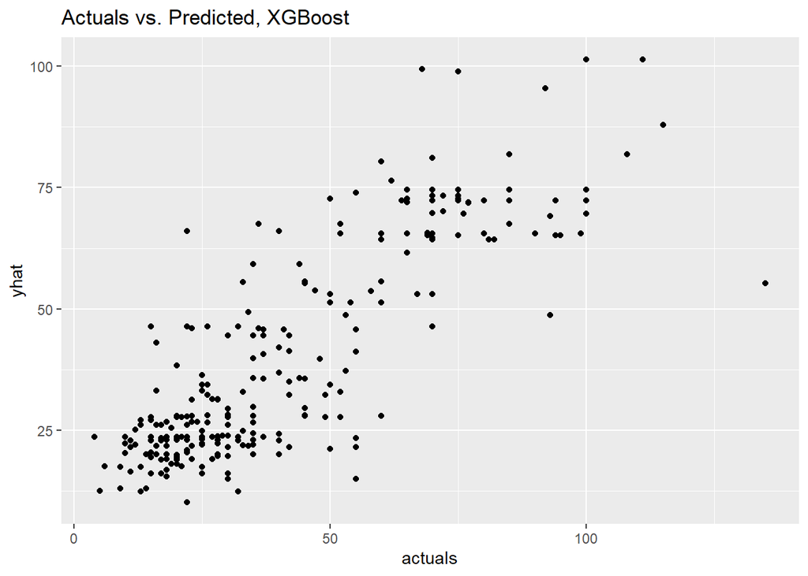

### Final accuracies. RMSE Is how much the average prediction is “off” by.

## The Random Forest is chosen as the optimal model.

# The random forest is an ensemble model that, at least in some ways, mimics the classic adage of “Wisdom of Crowds.”

# A random forest is a collection of decision trees, each one being trained on a different “Bootstrap Sample” of data, or a random sample with replacement.

# Additionally, at each bootstrap sample, a subset of features can be selected.

# So at each decision tree, a random sample of rows AND columns is selected and a model is built.

# Each tree’s output is then averaged to make a final prediction.

```
##    xg_rmse  rf_rmse  lm_rmse noskill_rmse
## 1 10.03874 9.586835 9.628729     21.34206
```

Using the optimal model (Random Forest) to predict all NA’s in the original IBU data

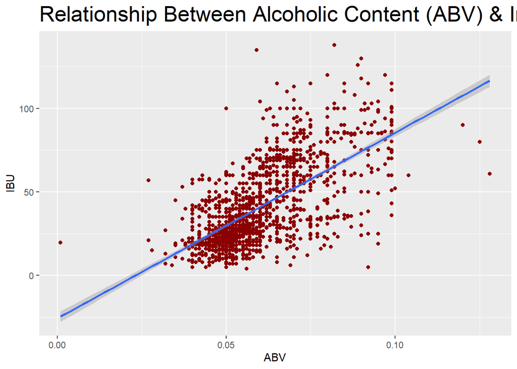